# prcticum 3

Simone Albuquerque

May 30, 2020

```r
knitr::opts_chunk$set(echo = TRUE)
#install.packages("DeclareDesign")
#install.packages("truncnorm")
library(DeclareDesign)
```

```r
library(truncnorm) #for truncated distribution
library(knitr)
library(ggplot2)
library(kableExtra)
```

## declare_population()

This functions allows you to declare the characteristics of the population that you want to study.

Population: City of Richmond low-income households viable for solar installation (3,000 households) - Treatment effect will be change in kw hour usage

```r
set.seed(228)
population <- declare_population(
  housholds = add_level(N=3000,
    kw_h=runif(n=N, min=600, max=13200),
    u=rnorm(n=N, mean=10972, sd=0.1))
)
#Variability in annual kw/h usage per household depending on climate throughout California (the variable 'u')
```

## Population descriptives

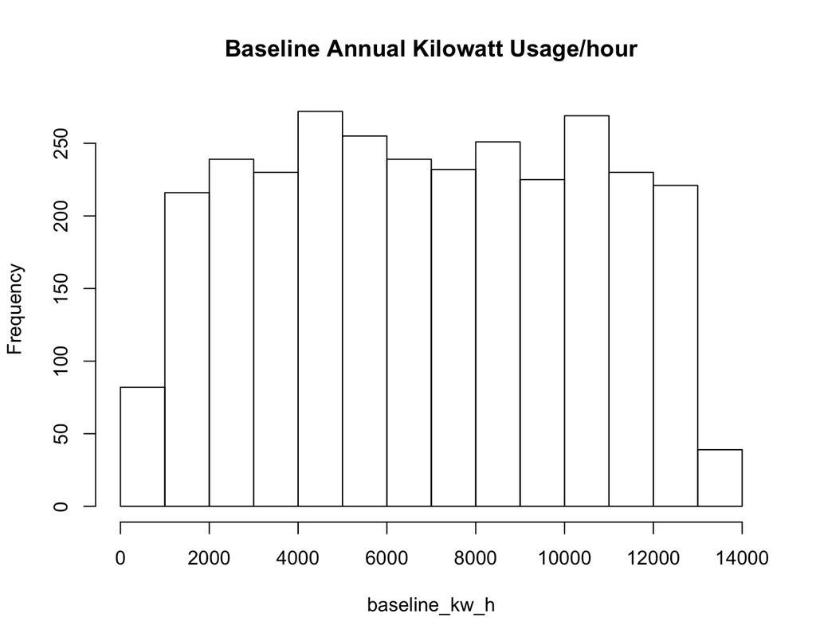

```r
pop <- population()
hist(pop[,2], xlab="baseline_kw_h",
     main="Baseline Annual Kilowatt Usage/hour", cex=24)
```

##declare_potential_outcomes()

The next step is to declare the full schedule of potential outcomes $Y(1)$ and $Y(0)$ under an assumption about the effect size of interest.

- We expect KW/H usage to decrease by 1642kWh per year ha in the treatment group and 658 the control group.

```r
potential_outcomes <-
  declare_potential_outcomes(
    Y_D_0= kw_h + u,
    Y_D_1=kw_h + u - 984)

#PH: we are proposing that the unit-level treatment effect is a +984 (or 1642 - 658) kW/h usage/year.
```

## Potential outcomes descriptives

```r
po <- potential_outcomes(pop)
kable(po[1:5,], digits=1)
```

| housholds | kw_h | u | Y_D_0 | Y_D_1 |
| --- | --- | --- | --- | --- |
| 0001 | 1182.1 | 10972.0 | 12154.2 | 11170.2 |
| 0002 | 10652.2 | 10972.0 | 21624.3 | 20640.3 |
| 0003 | 9577.3 | 10972.0 | 20549.3 | 19565.3 |
| 0004 | 6146.9 | 10972.0 | 17118.9 | 16134.9 |
| 0005 | 4397.5 | 10971.9 | 15369.5 | 14385.5 |

```r
#PH: spot check that our definition of the unit-level treatment effect is true (subtract column 4 from column 5).
```

## declare_sampling()

Next, we want to select the sample size. Let’s start with 1000 households (the actual study installed solar in 15,724 households across california and 3000 are eligible & suitable for solar in Richmond)

```r
sampling <- declare_sampling(n=1000) #n = 1000
sam <- sampling(po)
kable(sam[1:5,c(1:2,4:6)], row.names = FALSE,
      digits = 1)
```

| housholds | kw_h | Y_D_0 | Y_D_1 | S_inclusion_prob |
| --- | --- | --- | --- | --- |
| 0002 | 10652.2 | 21624.3 | 20640.3 | 0.3 |
| 0004 | 6146.9 | 17118.9 | 16134.9 | 0.3 |
| 0005 | 4397.5 | 15369.5 | 14385.5 | 0.3 |
| 0010 | 6764.7 | 17736.9 | 16752.9 | 0.3 |
| 0016 | 2736.2 | 13708.4 | 12724.4 | 0.3 |

## declare_assignment()

This step declares the random assignment process. There are many complexities, but let’s stick to *complete assignment* of exactly half the units at this stage.

```r
assigning <- declare_assignment(m = nrow(sam)/2,# number of rows of our sam
                  assignment_variable="D")
assigned <- assigning(sam) # keep the results

kable(assigned[1:5,c(1:2,4:5,7:8)],
      digits = 1)
```

| housholds | kw_h | Y_D_0 | Y_D_1 | D | D_cond_prob |
| --- | --- | --- | --- | --- | --- |
| 0002 | 10652.2 | 21624.3 | 20640.3 | 0 | 0.5 |
| 0004 | 6146.9 | 17118.9 | 16134.9 | 1 | 0.5 |
| 0005 | 4397.5 | 15369.5 | 14385.5 | 0 | 0.5 |
| 0010 | 6764.7 | 17736.9 | 16752.9 | 1 | 0.5 |
| 0016 | 2736.2 | 13708.4 | 12724.4 | 1 | 0.5 |

```r
#PH: alright, now we're using DeclareDesign to randomly assign households to treatment and control with a probability of 0.5. The variable 'm' denotes the number of units that declare_assignment() should place in each treatment condition, which we are asking to be equal to half of the sample per treatment condition (nrow(sam)/2).
```

## Assessing balance

At this stage, it’s possible to look at balance in the baseline kw/h annual usage, since random assignment has occured.

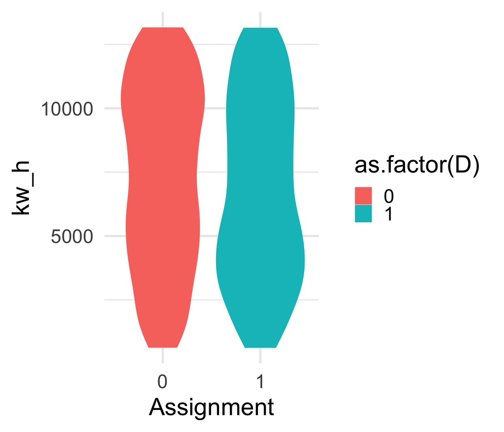

## declare_reveal()

This step declares how the potential outcomes are revealed by the random assignment

```r
revealing <- declare_reveal(assignment_variables=D) # the book of revelations

#PH: this part of DeclareDesign essentially is telling R which PO to reveal for each unit as a function of its treatment assignment. Recall that we calculated the full schedule of potential outcomes for each unit above.
```

## declare_estimand()

At this stage, we specify our target *estimand*, which is the quantity that we are trying to recover when estimating impact. Recall that we set this value to **984** in line with Jayachandran et al. (2017).

```r
estimand <- declare_estimand(ATE = -984) # we are looking for reduced kW/h usage
estimand(po)
```

```
##   estimand_label estimand
## 1            ATE     -984
```

## declare_estimator()

Next, we declare the estimators we use for recovering the estimand. While there are many advanced estimators, we’ll focus on the two core experimental estimators: 1. difference-in-means 2. difference-in-differences

```r
dim <- declare_estimator(Y ~ D, estimand = estimand,
          model =  difference_in_means, label = "DIM") #PH: Difference-in-means (Mean of treatment group - mean of control group)

did <- declare_estimator(Y - kw_h ~ D,
                         estimand = estimand,
          model =  difference_in_means, label = "DID") #PH: Difference-in-differences ([Mean of treatment group @ endline - Mean of treatment group @ baseline] - [Mean of control group @ endline - mean of control group @ baseline])
```

## declare_design()

This function brings all of the parts of the process together in a single design and allows for each part of the design to be simulated repeatedly.

```r
design <- population + potential_outcomes + sampling +
          assigning + revealing + estimand + dim + did
```

## diagnose_design()

At this stage, we can calculate various features of the design that we have specified

```r
diagnosis <- diagnose_design(design, sims=5000)
diagnosis$diagnosands_df[,c(1,3,5,9,11)] %>%
  kable()
```

| design_label | estimator_label | bias | power | coverage |
| --- | --- | --- | --- | --- |
| design | DID | 1968.000 | 1.0000 | 0 |
| design | DIM | 1965.821 | 0.9878 | 0 |

## Looking under the hood, DIM

[figure not shown]

```r
sim.out <- diagnosis$simulations
hist(sim.out$estimate[sim.out$estimator_label=="DIM"],
     main="Randomization Distribution",
     xlab="Estimates in Realized Experiments",
     xlim=c(-60,70), cex=24)
abline(v=5.5, lwd=3, col="red", add=T)
```

## Looking under the hood, DID

[figure not shown]

```r
sim.out <- diagnosis$simulations
hist(sim.out$estimate[sim.out$estimator_label=="DID"],
     main="Randomization Distribution",
     xlab="Estimates in Realized Experiments",
     xlim=c(-60,70), cex=24)
abline(v=5.5, lwd=3, col="red")
```

```r
#PH: note that we get more power using the difference in differences estimation. This is because diff-in-diff increases the precision of our estimate of the ATE.
```